# Lecture 11

Alex Shpenev

4/8/2021

This file is using the code of the following Datacamp project. Code is masked. https://projects.datacamp.com/projects/511

```
## # A tibble: 12,763 x 8
##    source  id_str text  created_at          retweet_count in_reply_to_use…
##    <chr>    <dbl> <chr> <dttm>                      <dbl>            <dbl>
##  1 Twitt… 6.83e17 "I w… 2015-12-31 23:21:49          6776               NA
##  2 Twitt… 6.83e17 "Do … 2015-12-31 23:11:35          2755               NA
##  3 Twitt… 6.83e17 "THA… 2015-12-31 18:51:12          2468               NA
##  4 Twitt… 6.83e17 "HAP… 2015-12-31 16:52:38          2080               NA
##  5 Twitt… 6.83e17 "I w… 2015-12-31 15:07:18          1875               NA
##  6 Twitt… 6.83e17 "#Ma… 2015-12-31 12:51:35          2285               NA
##  7 Twitt… 6.83e17 "\"@… 2015-12-31 11:01:18          1065               NA
##  8 Twitt… 6.83e17 "\"@… 2015-12-31 10:53:15          1432               NA
##  9 Twitt… 6.83e17 "\"@… 2015-12-31 10:46:30           676               NA
## 10 Twitt… 6.83e17 "\"@… 2015-12-31 10:42:47          1321               NA
## # … with 12,753 more rows, and 2 more variables: favorite_count <dbl>,
## #   is_retweet <lgl>
```

```
## # A tibble: 10 x 2
##    sentiment    `n()`
##    <chr>        <int>
##  1 anger         1247
##  2 anticipation   839
##  3 disgust       1058
##  4 fear          1476
##  5 joy            689
##  6 negative      3324
##  7 positive      2312
##  8 sadness       1191
##  9 surprise       534
## 10 trust         1231
```

How does tweeting from android/apple relate to the sentiment?

```
## # A tibble: 14 x 2
##    source                      n
##    <chr>                   <int>
##  1 Twitter for iPhone       6819
##  2 Twitter for Android      4388
##  3 Twitter Web Client       1167
##  4 Media Studio              154
##  5 Twitter Ads                97
##  6 Twitter for iPad           58
##  7 Twitter for BlackBerry     32
##  8 Instagram                  27
##  9 Twitter QandA              10
## 10 Periscope                   5
## 11 Facebook                    2
## 12 TweetDeck                   2
## 13 Mobile Web (M5)             1
## 14 Twitter Mirror for iPad     1
```

```
## # A tibble: 11,207 x 4
##     id_str source  text                                      created_at
##      <dbl> <chr>   <chr>                                     <dttm>
##  1 6.83e17 Android "I would like to wish everyone A HAPPY A… 2015-12-31 23:21:49
##  2 6.83e17 Android "Do you believe that The State Departmen… 2015-12-31 23:11:35
##  3 6.83e17 iPhone  "THANK YOU ILLINOIS! Let's not forget to… 2015-12-31 18:51:12
##  4 6.83e17 iPhone  "HAPPY BIRTHDAY to my son, @DonaldJTrump… 2015-12-31 16:52:38
##  5 6.83e17 Android "I would feel sorry for @JebBush and how… 2015-12-31 15:07:18
##  6 6.83e17 iPhone  "#MakeAmericaGreatAgain #Trump2016 https… 2015-12-31 12:51:35
##  7 6.83e17 Android "\"@whispers34: Nevada Poll: Donald Trum… 2015-12-31 11:01:18
##  8 6.83e17 Android "\"@deggow: Just heard a 25 year old man… 2015-12-31 10:53:15
##  9 6.83e17 Android "\"@wmsolomon: 'On Point' with Gov. Sara… 2015-12-31 10:46:30
## 10 6.83e17 Android "\"@stylin1188: Donald Trump is running … 2015-12-31 10:42:47
## # … with 11,197 more rows
```

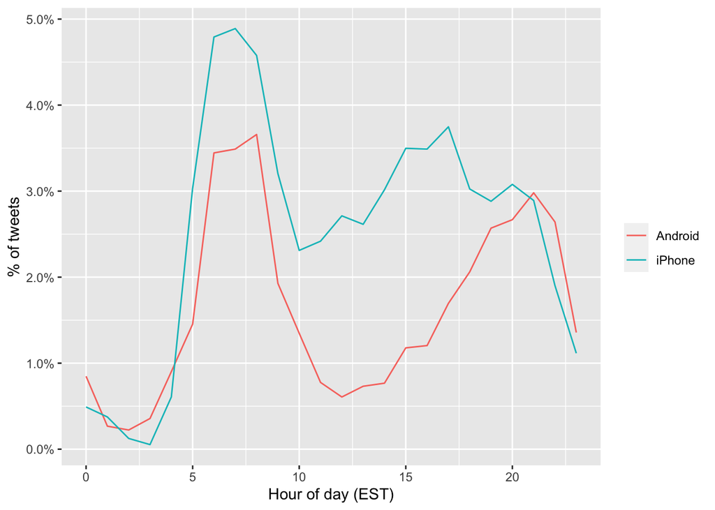

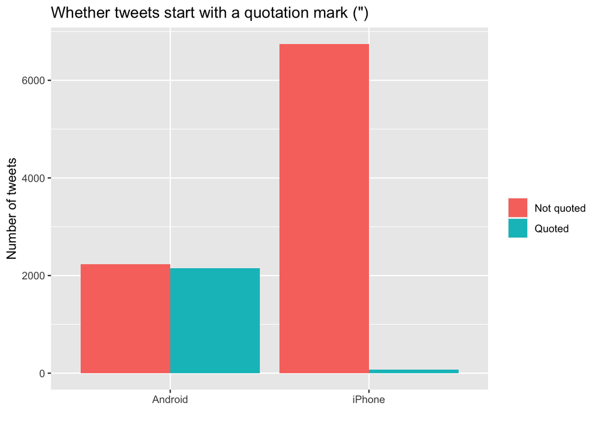

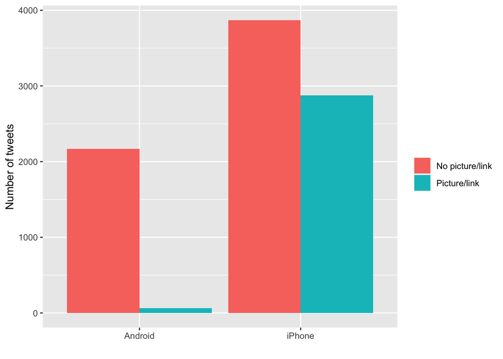

USE THIS FOR REFERENCE https://regexr.com/

```
## # A tibble: 6 x 4
##    id_str source  created_at          word
##     <dbl> <chr>   <dttm>              <chr>
## 1 6.83e17 Android 2015-12-31 23:21:49 happy
## 2 6.83e17 Android 2015-12-31 23:21:49 healthy
## 3 6.83e17 Android 2015-12-31 23:21:49 finally
## 4 6.83e17 Android 2015-12-31 23:21:49 america
## 5 6.83e17 Android 2015-12-31 23:21:49 safe
## 6 6.83e17 Android 2015-12-31 23:11:35 department
```

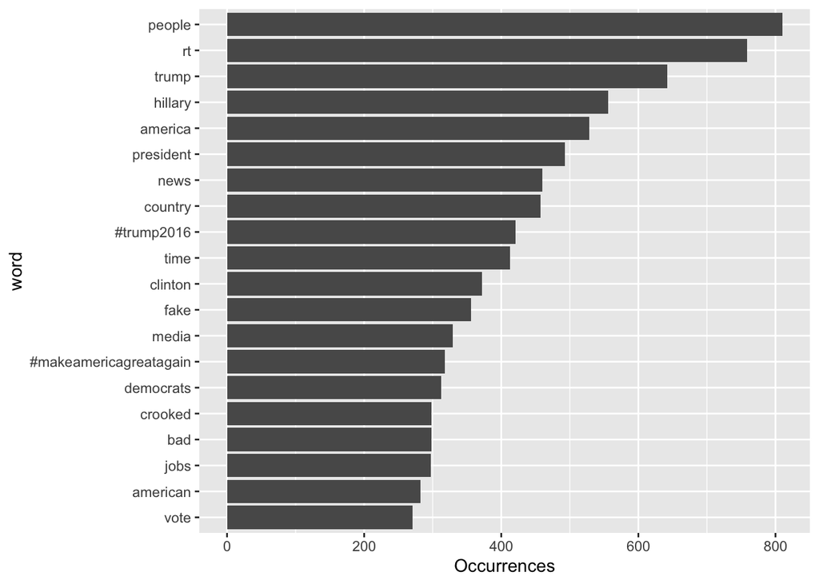

```
## # A tibble: 6 x 5
## # Groups:   sentiment [4]
##    id_str source  created_at          word    sentiment
##     <dbl> <chr>   <dttm>              <chr>   <chr>
## 1 6.83e17 Android 2015-12-31 23:21:49 happy   anticipation
## 2 6.83e17 Android 2015-12-31 23:21:49 happy   joy
## 3 6.83e17 Android 2015-12-31 23:21:49 happy   positive
## 4 6.83e17 Android 2015-12-31 23:21:49 happy   trust
## 5 6.83e17 Android 2015-12-31 23:21:49 healthy positive
## 6 6.83e17 Android 2015-12-31 23:21:49 finally anticipation
```

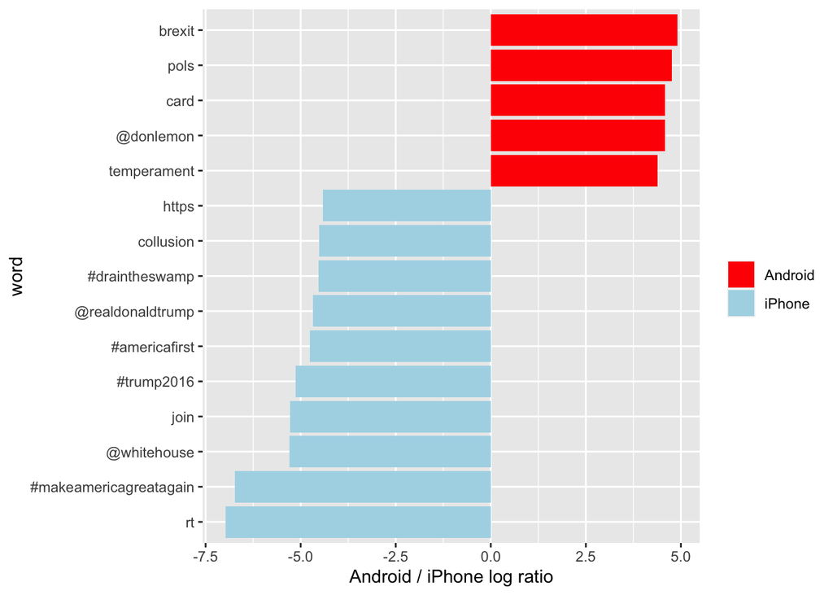

```
## # A tibble: 6 x 5
##   word       Android    iPhone logratio sentiment
##   <fct>        <dbl>     <dbl>    <dbl> <fct>
## 1 slaughter 0.000306 0.0000170     4.17 anger
## 2 slaughter 0.000306 0.0000170     4.17 disgust
## 3 slaughter 0.000306 0.0000170     4.17 fear
## 4 slaughter 0.000306 0.0000170     4.17 sadness
## 5 slaughter 0.000306 0.0000170     4.17 surprise
## 6 explain   0.000459 0.0000340     3.76 trust
```

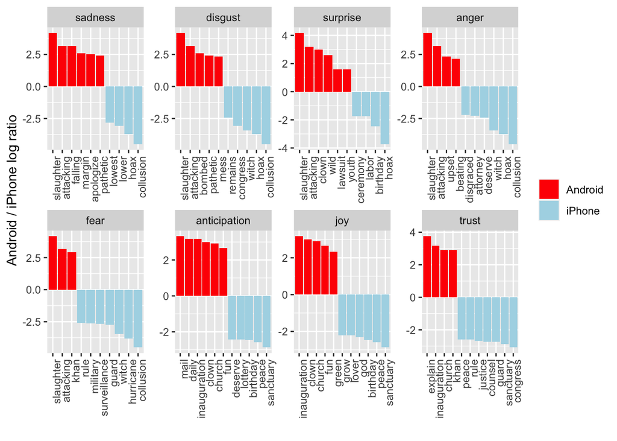

Feature extraction - Look at unstructured data, create new vars (e.g., time of day in terms of hours, quoted vs. non, picture vs. no, sentiment for each word) - Use new features to train model as to whether tweet is from android/iphone - DV - iPhone/android - IV = all those created variables/features

How to analyze dataset? Examine predictions - iPhone/android use as function of non-word features - Unnest a couple words at a time, not just singular words [but this might backfire: a) harder to clean jump, b) not all text will work]

Automate algorithm by trying to make predictions without going one by one through the data/being as reliant on the data

### Additional methods of classification?

#### 1) Naive bayes classifier; new info changes our estimations of probability

Green and red dice (5, and 4, respectively; 1/6 chances for each individaully)

without knowing color x2 5s, x2 4s = 1/18

knowing color x2 5s, x2 4s = 1/36, updates information

given that C happens, A’s probability is…? **P(A|C)** P(4|5) = 1/6 (throws are independent, nothing affects 4)

EX. home, work, bar P(bar) = 1/3 - Not accurate; needs updating.. what if it’s 5am? - Calculate P(bar|5am); P(bar|5am|saturday); additional features

*P(bar | time, weekend, weather, stress)* Traditional Bayes: creates long chain, connects everything - P(stress) x P(weather | stress) x P(weekend | weather, stress) x etc.

Naive Bayes: treats every additional factor independently - P(Bar) = P(bar|weather) x P(bar|weekend) x P(bar|stress) - Easier to calculate conditional probabilities, important since we often don’t have complete info

Good for text mining since it can use multiple words and see how one word might depend on prev word - All that amtters for new word to appear is the word prior to it

#### 2) Support Vector Machines (svm)

Similar to trees - use trees to separate data points, but they get complex very quickly - limited to horizontal/vertical cuts - More accurate, less flexible

svm can grow tree with single branch in different ways - one line = support vector (linear; can also be non-linear cuts) - complex trees not needed if there is way to rotate coordinates & make tree using diff coordinates - there will always be some error stil - More flexible

EX. for spiral data, support vector would not be as effective - When edge between clusters are extremely non-linear - base approach using accuracy metrics (if 2D data, svm generally better)